# Instructions

- **Be sure to read every question carefully and answer all parts.**
- **Clarification questions should be sent to the professors or TAs.** We will post to Piazza if everyone should see the answer. No consultation with other students or outside experts is allowed during the exam period (including R programming). You may use any notes / printed material / online resources.
- **Include all `R` code used to answer each question.** Be sure to include a command so that your results are printed out to the knitted output. Be sure to run all code again before submitting (Run -> Run All) so that all answers are included in your output.
- Some questions can be answered without any `R` code.
- **Use http://www.tablesgenerator.com/markdown_tables to easily convert excel tables to markdown** You can create your model tables in Excel, paste them into the website, and then copy the correctly formatted table back into this document.
- **Do not include your name in the file name.** We hide your names during grading to prevent bias.
- **Please proof-read your .nb.html file.** Submit both the .nb.html and the .Rmd file, but we will only grade the .nb.html file, so please make sure that it formatted right!

# Question 1 - part 1

A yield trial was performed at an English orchard to evaluate different management treatments for the ground between trees. The orchard was divided into blocks and each treatment(trt) was applied to a single row of each block. From each row, the total number of apples in the center 3 trees was counted at the end of the season (yield). The ‘S’ treatment was the standard practice of keeping the land clean in the summer.

```r
apples = read.csv('Apple_yield.csv',stringsAsFactors = TRUE)
str(apples)
```

```
## 'data.frame':    24 obs. of  4 variables:
##  $ row  : int  5 2 4 6 3 1 4 2 5 1 ...
##  $ block: Factor w/ 4 levels "B1","B2","B3",..: 1 1 1 1 1 1 2 2 2 2 ...
##  $ trt  : Factor w/ 6 levels "A","B","C","D",..: 1 2 3 4 5 6 1 2 3 4 ...
##  $ yield: num  290 274 278 265 274 ...
```

## 1.1 Create a design table for this experiment [8 points]

| Structure | Variable | Type | # levels | EU |
| --- | --- | --- | --- | --- |
| Treatment | trt | categorical | 6 | block:trt |
| Design | block:trt | categorical | 24 |  |
|  | block:row | categorical | 24 |  |
|  | block | categorical | 4 |  |
| Response | yield | numeric | 24 |  |

## 1.2 Write an appropriate linear model for the analysis [4 points]

```r
# converting to factors
apples$row <- as.factor(apples$row)

# the model
apples_model <- lm(yield ~ block + trt, data = apples)
```

## 1.3 Can you conclude that any of the ground managment techniques increase yield relative to the control ‘S’? [5 points]

Use alpha = 0.05.

```r
apples_means = emmeans(apples_model, specs = 'trt')
trt_effects = contrast(apples_means, method = 'trt.vs.ctrl', ref = 'S')
summary(trt_effects, level = 0.95, infer=T)
```

|  | contrast | estimate | SE | df | lower.CL | upper.CL | t.ratio | p.value |
| --- | --- | --- | --- | --- | --- | --- | --- | --- |
| 1 | A - S | 29.71618 | 11.39636 | 15 | -2.621800 | 62.05417 | 2.607516 | 0.077062360 |
| 2 | B - S | 15.87397 | 11.39636 | 15 | -16.464013 | 48.21195 | 1.392899 | 0.511981088 |
| 3 | C - S | 23.37397 | 11.39636 | 15 | -8.964013 | 55.71195 | 2.051004 | 0.203859749 |
| 4 | D - S | 30.73206 | 11.39636 | 15 | -1.605921 | 63.07005 | 2.696657 | 0.065269381 |
| 5 | E - S | 50.81710 | 11.39636 | 15 | 18.479117 | 83.15508 | 4.459066 | 0.002037807 |

> Yes, treatments E results in significantly higher yields than the control treatment, S. The other treatments, including treatment D does not meet our cutoff for significance (p-value < 0.05).

# Question 1 - part 2

Given these promising results, you decide to expand the experiment by adding two additional orchards. You replicate the same design over those two additional orchards and add them to your data table.

```r
apples_2 = read.csv('Apples_yield_2.csv',stringsAsFactors = FALSE)
str(apples_2)
```

```
## 'data.frame':    72 obs. of  4 variables:
##  $ Field: int  1 1 1 1 1 1 1 1 1 1 ...
##  $ block: chr  "1.B1" "1.B1" "1.B1" "1.B1" ...
##  $ trt  : chr  "A" "B" "C" "D" ...
##  $ yield: num  290 274 278 265 274 ...
```

## 1.4 Create a design table for this larger experiment [8 points]

| Structure | Variable | Type | # levels | EU |
| --- | --- | --- | --- | --- |
| Treatment | trt | categorical | 6 | field:trt |
| Design | field:trt | categorical | 18 |  |
|  | block:trt | categorical | 72 |  |
|  | field:block:trt | categorical | 72 |  |
|  | field | categorical | 3 |  |
|  | block | categorical | 12 |  |
| Response | yield | numeric | 72 |  |

> Note, field:block:trt is not strictly necessary to include, as block has been renamed so that they are already uniquely identifieable to the field they are in. Field:block and block are aliased. For example Field 1, block 2 is 1.B2.

## 1.5 Write an appropriate linear model for the analysis [4 points]

```r
# converting field to factor
apples_2$Field <- as.factor(apples_2$Field)

# checking crosses, nesting
is_nested(Field:trt ~ block, apples_2 ) # FALSE
```

```
## [1] FALSE
```

```r
is_nested(block ~ Field:trt, apples_2)  # FALSE
```

```
## [1] FALSE
```

```r
is_crossed(Field:trt ~ block, apples_2) # TRUE
```

```
## [1] TRUE
```

```r
is_nested(Field ~ Field:trt, apples_2)  # TRUE
```

```
## [1] TRUE
```

```r
is_nested(Field ~ block, apples_2)      # TRUE
```

```
## [1] TRUE
```

```r
# the model
apples_2_model <- lmer(yield ~ (1|Field:trt) + block + Field + trt, data = apples_2)
```

```
## fixed-effect model matrix is rank deficient so dropping 2 columns / coefficients
```

## 1.6 Compare the results of this larger experiment to the first experiment. [6 points]

Have your conclusions changed? You’ve done 3x the work. Have you gained precision in your estimates relative to the first (smaller experiment)? Why or why not? How has the *interpretation* of your treatment effects changed with the new experiment?

```r
apples_2_means = emmeans(apples_2_model, specs = 'trt')
```

```
## NOTE: A nesting structure was detected in the fitted model:
##     block %in% Field
```

```r
trt_effects_2 = contrast(apples_2_means, method = 'trt.vs.ctrl', ref = 'S')
summary(trt_effects_2, level = 0.95, infer=T)
```

|  | contrast | estimate | SE | df | lower.CL | upper.CL | t.ratio | p.value |
| --- | --- | --- | --- | --- | --- | --- | --- | --- |
| 1 | A - S | 34.17805 | 14.23092 | 10 | -8.771425 | 77.12752 | 2.401675 | 0.13354052 |
| 2 | B - S | 26.67161 | 14.23092 | 10 | -16.277859 | 69.62109 | 1.874202 | 0.29004399 |
| 3 | C - S | 26.06227 | 14.23092 | 10 | -16.887199 | 69.01174 | 1.831384 | 0.30740777 |
| 4 | D - S | 25.53003 | 14.23092 | 10 | -17.419444 | 68.47950 | 1.793983 | 0.32317655 |
| 5 | E - S | 51.92674 | 14.23092 | 10 | 8.977265 | 94.87621 | 3.648867 | 0.01804917 |

> No, the general conclusion is still the same: E has a significantly higher yield than the standard treatment, S and the other treatments make no significant difference in yield. Our precision has decreased, as our confidence intervals have grown larger than those observed in the single orchard experiment. Our CIs have grown larger, in part, because our degrees of freedom have decreased. This is because the orchards become our new, external block (b=3) versus the four blocks in the first experiment (b=4). Additionally, our data seems to have more spread, as indicated by the SE being larger in the second experiment. Despite having less precision, our results are more generalizeable as treatment E was effective at increasing yield across 3 different orchards.

# Question 2

A researcher ran a microcosm experiment to study the effect of nitrogen runoff on biodiversity in wetland communities. They were interested in how weeds might out-compete native grasses under elevated nitrogen levels. They chose three weed species to test. The experiment was run in small artificial wetlands (rectangular wire baskets) that included a combination of a native grass and single weed species.

The artificial wetlands were set in large trays with water containing a defined level of nitrogen. In total, there were 8 trays, with two trays for each of the four levels of nitrogen. Each tray held three artificial wetlands, one for each of the three weed species.

At the end of 8 weeks, the plant material in each wetland was harvested and divided between weed and native grass, and the percentage of biomass that remained as grass was recorded.

```r
biomass_1 = read.csv('weed_biomass_small.csv',stringsAsFactors = TRUE)
str(biomass_1)
```

```
## 'data.frame':    24 obs. of  5 variables:
##  $ tray        : Factor w/ 8 levels "Tray_1","Tray_2",..: 1 1 1 2 2 2 3 3 3 4 ...
##  $ wetland     : Factor w/ 24 levels "Wetland_1","Wetland_10",..: 1 12 18 19 20 21 22 23 24 2 ...
##  $ nitrogen    : Factor w/ 4 levels "Nitr_1","Nitr_2",..: 1 1 1 2 2 2 3 3 3 4 ...
##  $ weed        : Factor w/ 3 levels "Weed_1","Weed_2",..: 1 2 3 1 2 3 1 2 3 1 ...
##  $ perc_biomass: num  87.2 70.4 75.9 80.5 59.2 59.5 76.8 47.8 48.4 77.7 ...
```

## 2.1 Create a design table for this experiment [8 points]

Give a justification for each EU that you specify.

| Structure | Variable | Type | # levels | EU |
| --- | --- | --- | --- | --- |
| Treatment | nitrogen | factor | 4 | tray |
|  | weed | factor | 3 | tray:weed |
|  | nitrogen:weed | factor | 12 | tray:nitrogen:weed |
| Design | tray | factor | 8 |  |
|  | tray:weed | factor | 24 |  |
|  | tray:nitrogen:weed | factor | 24 |  |
|  | wetland | factor | 24 |  |
| Response | perc_biomass | numerical | 24 |  |

> Because the randomization process happens separately for the different treatments, the EUs for nitrogen, weed, and nitrogen:weed are different. The nitrogen treatment is more restricted, and is thus applied/randomized at the EU level, tray. The less restricted factor, weed, is applied at the wetland (basket) level. However, because wetland is nested within tray, we use tray:weed as our EU because tray is the outer block. Similarly, the nitrogen:weed treatment is applied at the wetland level, which is nested within tray, so our EU is tray:nitrogen:weed.

## 2.2 Write an appropriate linear model for the analysis [4 points]

```r
#checking nesting, crossed, aliased
is_nested(wetland ~ tray, biomass_1)   # FALSE
```

```
## [1] FALSE
```

```r
is_crossed(wetland ~ tray, biomass_1)  # FALSE
```

```
## [1] FALSE
```

```r
is_nested(tray ~ tray:weed, biomass_1) # TRUE
```

```
## [1] TRUE
```

```r
# biomass model
biomass_1_model <- lmer(perc_biomass ~ nitrogen + weed + nitrogen:weed + (1|tray), data = biomass_1)
```

## 2.3 How much evidence do you have that nitrogen levels EVER affect the proportion of non-weed biomass? [6 points]

Use an ANOVA to answer this question. Provide a statement describing the interpretation of the ANOVA results. Be very specific about how you measured the evidence and what you can conclude from this analysis.

```r
# Does nitrogen ever affect biomass?
anova(biomass_1_model, ddf = 'K')
```

|  | Sum Sq | Mean Sq | NumDF | DenDF | F value | Pr(>F) |
| --- | --- | --- | --- | --- | --- | --- |
| nitrogen | 127.4667 | 42.48890 | 3 | 4 | 16.44732 | 1.027610e-02 |
| weed | 3540.1808 | 1770.09042 | 2 | 8 | 685.19629 | 1.134667e-09 |
| nitrogen:weed | 448.6458 | 74.77431 | 6 | 8 | 28.94489 | 5.250459e-05 |

> There is evidence that nitrogen has an effect on biomass (p = 0.01028). Additionally, the F value is relatively high (F value = 16.447) meaning that variation due to nitrogen (between trays) is higher than variation within a tray. This means that nitrogen levels explain at least part of the variation in biomass that we observe. We can not conclude how different nitrogen levels affects the biomass of the different weed treatments. We also can not determine which nitrogen treatments resulted in the highest or lowest biomass.

## 2.4 Estimate the effects of changing nitrogen levels on the percent of non-weed biomass [6 points]

Present a table/display giving estimates and confidence intervals for the nitrogen effects. Use 95% confidence intervals adjusted for the number of comparisons. Describe the findings. You do not need to specifically describe each contrast, but provide an overall summary of the main findings. You may include a figure if you’d like.

```r
# specific effects - nitrogen at each level of weed
biomass_1_specific_means <- emmeans(biomass_1_model, specs = 'nitrogen', by = 'weed')
biomass_1_specific_effects <- contrast(biomass_1_specific_means, method = 'pairwise')
cld(biomass_1_specific_means, alpha = 0.05/3)
```

|  | nitrogen | weed | emmean | SE | df | lower.CL | upper.CL | .group |
| --- | --- | --- | --- | --- | --- | --- | --- | --- |
| 4 | Nitr_4 | Weed_1 | 76.60 | 2.512801 | 5.29701 | 70.24807 | 82.95193 | 1 |
| 3 | Nitr_3 | Weed_1 | 79.60 | 2.512801 | 5.29701 | 73.24807 | 85.95193 | 1 |
| 2 | Nitr_2 | Weed_1 | 80.15 | 2.512801 | 5.29701 | 73.79807 | 86.50193 | 1 |
| 1 | Nitr_1 | Weed_1 | 82.70 | 2.512801 | 5.29701 | 76.34807 | 89.05193 | 1 |
| 8 | Nitr_4 | Weed_2 | 37.35 | 2.512801 | 5.29701 | 30.99807 | 43.70193 | 1 |
| 7 | Nitr_3 | Weed_2 | 49.15 | 2.512801 | 5.29701 | 42.79807 | 55.50193 | 12 |
| 6 | Nitr_2 | Weed_2 | 58.40 | 2.512801 | 5.29701 | 52.04807 | 64.75193 | 23 |
| 5 | Nitr_1 | Weed_2 | 67.75 | 2.512801 | 5.29701 | 61.39807 | 74.10193 | 3 |
| 12 | Nitr_4 | Weed_3 | 40.10 | 2.512801 | 5.29701 | 33.74807 | 46.45193 | 1 |
| 11 | Nitr_3 | Weed_3 | 50.00 | 2.512801 | 5.29701 | 43.64807 | 56.35193 | 12 |

[output cut: 2 more lines]

```r
summary(biomass_1_specific_effects, infer = T, level =1-0.05/3)
```

|  | contrast | weed | estimate | SE | df | lower.CL | upper.CL | t.ratio | p.value |
| --- | --- | --- | --- | --- | --- | --- | --- | --- | --- |
| 1 | Nitr_1 - Nitr_2 | Weed_1 | 2.55 | 3.553637 | 5.29701 | -14.29576 | 19.39576 | 0.7175748 | 0.886377141 |
| 2 | Nitr_1 - Nitr_3 | Weed_1 | 3.10 | 3.553637 | 5.29701 | -13.74576 | 19.94576 | 0.8723458 | 0.819183727 |
| 3 | Nitr_1 - Nitr_4 | Weed_1 | 6.10 | 3.553637 | 5.29701 | -10.74576 | 22.94576 | 1.7165514 | 0.400374817 |
| 4 | Nitr_2 - Nitr_3 | Weed_1 | 0.55 | 3.553637 | 5.29701 | -16.29576 | 17.39576 | 0.1547710 | 0.998510609 |
| 5 | Nitr_2 - Nitr_4 | Weed_1 | 3.55 | 3.553637 | 5.29701 | -13.29576 | 20.39576 | 0.9989766 | 0.756755732 |
| 6 | Nitr_3 - Nitr_4 | Weed_1 | 3.00 | 3.553637 | 5.29701 | -13.84576 | 19.84576 | 0.8442056 | 0.832273099 |
| 7 | Nitr_1 - Nitr_2 | Weed_2 | 9.35 | 3.553637 | 5.29701 | -7.49576 | 26.19576 | 2.6311075 | 0.145491659 |
| 8 | Nitr_1 - Nitr_3 | Weed_2 | 18.60 | 3.553637 | 5.29701 | 1.75424 | 35.44576 | 5.2340748 | 0.010813518 |
| 9 | Nitr_1 - Nitr_4 | Weed_2 | 30.40 | 3.553637 | 5.29701 | 13.55424 | 47.24576 | 8.5546169 | 0.001061326 |
| 10 | Nitr_2 - Nitr_3 | Weed_2 | 9.25 | 3.553637 | 5.29701 | -7.59576 | 26.09576 | 2.6029673 | 0.150178013 |

[output cut: 8 more lines]

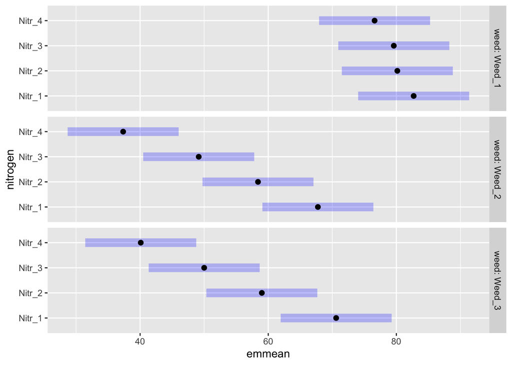

```r
plot(biomass_1_specific_means, level = 1-(0.05/3))
```

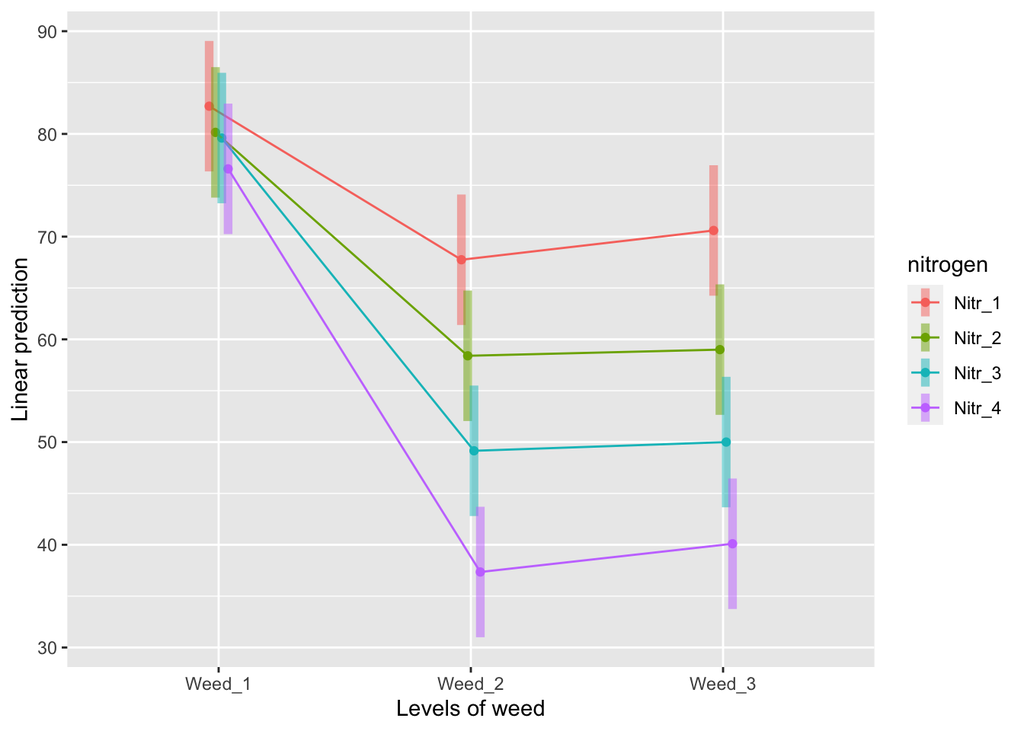

```r
emmip(biomass_1_model, nitrogen~weed, CIs = T)
```

> Biomass for Weed_1 was not affected by the four different Nitrogen treatments. This is shown by the cld analysis, but it is also apparent in the figure, where the means are tightly clustered for Weed_1 versus Weed_2 and Weed_3 which are much more spread out. The Nitr_1 treatment had the highest biomass across weed treatments, but it was only distinguishable from Nitr_3 and Nitr_4 for both Weed_2 and Weed_3.

## 2.5 You should have observed above that effects of nitrogen appear much greater for some weed species than others. [6 points]

Test this hypothesis using an ANOVA. Then estimate how much the nitrogen effects change for species “Weed_2” relative to species “Weed_1”. Describe the findings. Include a description of an example interaction effect.

```r
# Is the effect of nitrogen greater for some weed species than others?
# Nitrogen is the specific effect, so we drop it from the model
biomass_1_specific <- lmer(perc_biomass ~ weed + nitrogen:weed + (1|tray), data = biomass_1)

# specific effect anova
anova(biomass_1_specific, ddf = 'K')
```

|  | Sum Sq | Mean Sq | NumDF | DenDF | F value | Pr(>F) |
| --- | --- | --- | --- | --- | --- | --- |
| weed | 252.0233 | 126.01167 | 2 | 8.00000 | 48.77871 | 3.299171e-05 |
| weed:nitrogen | 576.1126 | 64.01251 | 9 | 6.91585 | 23.24021 | 2.252748e-04 |

```r
# How much do the nitrogen effects change for Weed_2 relative to Weed_1?
biomass_1_specific_means <- emmeans(biomass_1_model, specs = 'weed', by = 'nitrogen')
biomass_1_specific_effects <- contrast(biomass_1_specific_means, method = 'trt.vs.ctrl', ref = 'Weed_1')
nitrogen_effects_by_contrast <- emmeans(biomass_1_specific_effects, spec = 'nitrogen', by = 'contrast')
biomass_1_interaction <- contrast(nitrogen_effects_by_contrast, method = 'pairwise')
summary(biomass_1_interaction, infer = T, level = 1-0.05/3)
```

|  | contrast1 | contrast | estimate | SE | df | lower.CL | upper.CL | t.ratio | p.value |
| --- | --- | --- | --- | --- | --- | --- | --- | --- | --- |
| 1 | Nitr_1 - Nitr_2 | Weed_2 - Weed_1 | 6.80 | 2.27303 | 8 | -2.29078553 | 15.89079 | 2.991601 | 6.730800e-02 |
| 2 | Nitr_1 - Nitr_3 | Weed_2 - Weed_1 | 15.50 | 2.27303 | 8 | 6.40921447 | 24.59079 | 6.819091 | 6.154496e-04 |
| 3 | Nitr_1 - Nitr_4 | Weed_2 - Weed_1 | 24.30 | 2.27303 | 8 | 15.20921447 | 33.39079 | 10.690575 | 2.403951e-05 |
| 4 | Nitr_2 - Nitr_3 | Weed_2 - Weed_1 | 8.70 | 2.27303 | 8 | -0.39078553 | 17.79079 | 3.827490 | 2.102129e-02 |
| 5 | Nitr_2 - Nitr_4 | Weed_2 - Weed_1 | 17.50 | 2.27303 | 8 | 8.40921447 | 26.59079 | 7.698974 | 2.642261e-04 |
| 6 | Nitr_3 - Nitr_4 | Weed_2 - Weed_1 | 8.80 | 2.27303 | 8 | -0.29078553 | 17.89079 | 3.871484 | 1.980313e-02 |
| 7 | Nitr_1 - Nitr_2 | Weed_3 - Weed_1 | 9.05 | 2.27303 | 8 | -0.04078553 | 18.14079 | 3.981469 | 1.707285e-02 |
| 8 | Nitr_1 - Nitr_3 | Weed_3 - Weed_1 | 17.50 | 2.27303 | 8 | 8.40921447 | 26.59079 | 7.698974 | 2.642261e-04 |
| 9 | Nitr_1 - Nitr_4 | Weed_3 - Weed_1 | 24.40 | 2.27303 | 8 | 15.30921447 | 33.49079 | 10.734569 | 2.331136e-05 |
| 10 | Nitr_2 - Nitr_3 | Weed_3 - Weed_1 | 8.45 | 2.27303 | 8 | -0.64078553 | 17.54079 | 3.717504 | 2.442539e-02 |

[output cut: 2 more lines]

## 2.6 Which specific effects would you expect to be estimated with the greatest precision? Why? [5 points]

The previous questions used nitrogen as the focal treatment and calculated specific effects of nitrogen for each weed species. We could have instead treated weed species as the focal treatment and calculated specific effects for each level of nitrogen. Would each specific effect in each set have the same standard error and size of its confidence interval? Why or why not?

> The comparisons between weeds, within a tray (nitrogen treatment) would be the most precise because they are happening within the same block. Any variation due to the tray will be expected to be applied equally to each weed treatment within that tray. As a result, we can expect out CIs to be smaller. Thus I would expect weed as the specific effect to have the greatest precision. Each specific effect per set would have the same SE but different CIs. The SE would be unaffected because the population sizes and variance would not change if we considered weed as the specific effect versus nitrogen.

# Challenge problem: (5 bonus points but only if 100% correct. Max score = 70)

The above data set is from a classic experiment used to demonstrate split plots. In the original experiment, each of the 24 wetlands was further divided into two halves, and one half was randomly selected for trimming (clipping) to simulate mowing after 1 week. Furthermore, the 8 trays were divided between two tables, with one tray/nitrogen level on each table. Create the design table for this experiment and write the corresponding linear model

```r
biomass_full = read.csv('weed_biomass2.csv',stringsAsFactors = TRUE)
str(biomass_full)
```

```
## 'data.frame':    48 obs. of  7 variables:
##  $ table       : Factor w/ 2 levels "Table1","Table2": 1 1 1 1 1 1 1 1 1 1 ...
##  $ tray        : Factor w/ 8 levels "Tray_1","Tray_2",..: 1 1 1 1 1 1 2 2 2 2 ...
##  $ wetland     : Factor w/ 24 levels "Wetland_1","Wetland_10",..: 1 1 12 12 18 18 19 19 20 20 ...
##  $ nitrogen    : Factor w/ 4 levels "Nitr_1","Nitr_2",..: 1 1 1 1 1 1 2 2 2 2 ...
##  $ clipping    : Factor w/ 2 levels "cut","none": 2 1 2 1 2 1 2 1 2 1 ...
##  $ weed        : Factor w/ 3 levels "Weed_1","Weed_2",..: 1 1 2 2 3 3 1 1 2 2 ...
##  $ perc_biomass: num  87.2 88.8 70.4 75.7 75.9 80.6 80.5 83.8 59.2 61.5 ...
```

| Structure | Variable | Type | # levels | EU |
| --- | --- | --- | --- | --- |
| Treatment | nitrogen | factorial | 4 | table:nitrogen |
|  | weed | factorial | 3 | table:weed |
|  | clipping | factorial | 2 | table:clipping |
|  | nitrogen:weed | factorial | 12 | table:nitrogen:weed |
|  | nitrogen:clipping | factorial | 8 | table:nitrogen:clipping |
|  | weed:clipping | factorial | 6 | table:weed:clipping |
|  | nitrogen:weed:clipping | factorial | 24 | table:nitrogen:weed:clipping |
| Design | table:nitrogen | factorial | 8 |  |
|  | table:weed | factorial | 6 |  |
|  | table:clipping | factorial | 4 |  |
|  | table:nitrogen:weed | factorial | 24 |  |
|  | table:nitrogen:clipping | factorial | 16 |  |
|  | table:weed:clipping | factorial | 12 |  |
|  | table:nitrogen:weed:clipping | factorial | 48 |  |
|  | table | factorial | 2 |  |
|  | tray | factorial | 8 |  |
|  | wetland | factorial | 24 |  |
| Response | perc_biomass | numeric | 48 |  |

```r
is_crossed(tray ~ weed, biomass_full)
```

```
## [1] TRUE
```

```r
is_crossed(tray ~ weed:clipping, biomass_full)
```

```
## [1] TRUE
```

```r
is_crossed(wetland ~ clipping, biomass_full)
```

```
## [1] TRUE
```

```r
is_crossed(tray ~ wetland, biomass_full)
```

```
## [1] FALSE
```

```r
is_crossed(table ~ tray, biomass_full)
```

```
## [1] FALSE
```

```r
is_crossed(table ~ wetland, biomass_full)
```

```
## [1] FALSE
```

```r
is_nested(nitrogen ~ tray:nitrogen:weed:clipping, biomass_full)
```

```
## [1] TRUE
```

```r
is_nested(weed ~ tray:nitrogen:weed:clipping, biomass_full)
```

```
## [1] TRUE
```

```r
is_nested(clipping ~ tray:nitrogen:weed:clipping, biomass_full)
```

```
## [1] TRUE
```

```r
is_nested(nitrogen ~ tray, biomass_full)
```

```
## [1] TRUE
```

```r
is_aliased(tray:nitrogen:weed:clipping ~ table:nitrogen:weed:clipping, biomass_full)
```

```
## [1] TRUE
```

```r
is_aliased(tray:weed:clipping ~ table:nitrogen:weed:clipping, biomass_full)
```

```
## [1] TRUE
```

```r
is_aliased(tray:weed ~ table:nitrogen:weed:clipping, biomass_full)
```

```
## [1] FALSE
```

```r
is_aliased(wetland:clipping ~ table:nitrogen:weed:clipping, biomass_full)
```

```
## [1] TRUE
```

```r
# the model

biomass_full_model <- lmer(perc_biomass ~ nitrogen + weed + clipping + nitrogen:weed + nitrogen:clipping + weed:clipping + nitrogen:weed:clipping + (1|table:nitrogen) + (1|table:weed) + (1|table:clipping) + (1|table:nitrogen:weed) + (1|table:nitrogen:clipping) + table + tray + wetland, data = biomass_full)
```

```
## fixed-effect model matrix is rank deficient so dropping 19 columns / coefficients
```

```
## boundary (singular) fit: see ?isSingular
```

```r
biomass_1_model <- lmer(perc_biomass ~ nitrogen + weed + nitrogen:weed + (1|tray), data = biomass_1)
```